# NASDAQ Scraper & Analysis

#### sentiment Analysis for Companies:

Our aim here is to come up with a unified sentiment score for each company and accordingly assign a final decision to either Buy, Hold or Sell the company’s stocks for each company

```r
Company_sentiments <- nasdaq_data %>%
    mutate(mean_Score= rowMeans(data.frame(News_Score, Media_Score, HedgeFund_Score, Investor_Score)))

Company_sentiments$Decision <- cut(as.numeric(Company_sentiments$mean_Score), 5,
                        labels = c("Strong_sell", "Moderate_sell", "Hold", "Moderate_buy", "strong_buy"))

Companies_Decision <- Company_sentiments %>%
    group_by(Sector, Company, Decision) %>%
    select(Company, mean_Score, Decision)
Companies_Decision
```

```
## # A tibble: 6,080 x 4
## # Groups:   Sector, Company, Decision [6,022]
##    Sector         Company              mean_Score Decision
##    <chr>          <chr>                     <dbl> <fct>
##  1 Consumer Goods Apple                     0.605 Hold
##  2 Technology     Microsoft                 0.561 Hold
##  3 Services       Amazon                    0.797 strong_buy
##  4 Technology     Alphabet                  0.565 Hold
##  5 Technology     Facebook                  0.628 Moderate_buy
##  6 Financial      Berkshire Hathaway A      0.419 Moderate_sell
##  7 Financial      Berkshire Hathaway B      0.677 Moderate_buy
##  8 Services       Alibaba                   0.798 strong_buy
##  9 Financial      JPMorgan Chase & Co.      0.485 Hold
## 10 Technology     Tencent Holdings          0.698 Moderate_buy
## # ... with 6,070 more rows
```

For each listed company, we now have a mean score and a final decision for stock trading. A mean score of zero indicates that now is the perfect time to sell the shares and a score of 1 favors the buying of more stocks of a company. To finally summarise our findings in a single graph, we see the different decisions per sector for each company to see which Sectors have the best opportunity to buy, hold or sell stocks

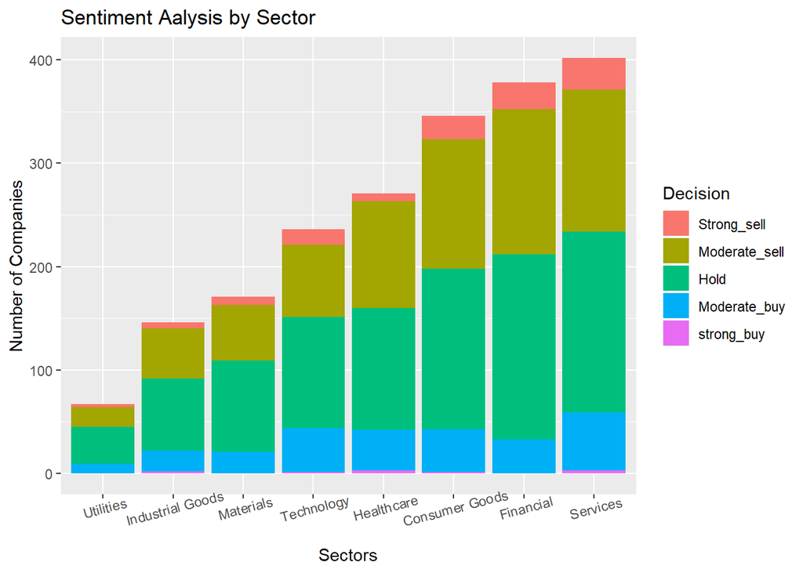

```r
ggplot(data = na.omit(Companies_Decision)) +
    geom_bar(mapping = aes(x = Sector, fill = Decision)) +
    scale_x_discrete(limits=c("Utilities", "Industrial Goods", "Materials", "Technology",
                              "Healthcare", "Consumer Goods", "Financial", "Services")) +
    theme(axis.text.x = element_text(angle = 15)) +
    labs(x = "Sectors",
         y = "Number of Companies",
         title = "Sentiment Aalysis by Sector")
```

We can conclude that the best selling opportunites are for the Services, Financial and the Consumer Goods Sector. The dataset indicates that very few companies currently have good buying opportunities and overall holding the stocks for almost all sectors is most advisable.

The final submission contians a Companies_Decision.csv file for the complete list of decisions for each company.